# IE 48B — Homework 1

Exploring Time Series through Time and Frequency Domains

Author

Yunus Emre Camızcı | Student ID: 2021402078

Published

March 23, 2026

**ImportantDataset Assignment**

Each student is assigned a **unique** dataset from the [UCR Time Series Classification Archive](https://www.timeseriesclassification.com/). Find your student ID in the table below to identify your dataset. All analysis must be performed on **your assigned dataset** — submissions using a different dataset receive zero credit.

| Student ID | Dataset |
| --- | --- |
| 2019***078 | Rock |
| 2020***162 | Beef |
| 2020***180 | ShapeletSim |
| 2020***240 | Ham |
| 2021***015 | Wafer |
| 2021***051 | Herring |
| 2021***054 | FaceFour |
| 2021***069 | GunPoint |
| 2021***078 | Coffee |
| 2021***153 | ECGFiveDays |
| 2021***162 | Trace |
| 2021***174 | OSULeaf |
| 2021***216 | SyntheticControl |
| 2021***264 | MedicalImages |
| 2021***273 | Plane |
| 2021***309 | Strawberry |
| 2022***249 | ECG200 |
| 2022***270 | CBF |
| 2023***219 | ItalyPowerDemand |
| 2023***255 | TwoLeadECG |
| 2024***003 | Wine |
| 2024***066 | SonyAIBORobotSurface1 |
| 2024***279 | Lightning2 |
| 2024***294 | BeetleFly |
| 2025***069 | FordA |
| 2025***081 | Fish |

Dataset details (classes, train/test sizes, domain) are in the homework PDF.

> **Reproducibility requirement:** Set your random seed using your student ID in every code block that uses randomisation (e.g. `set.seed(XXXXXXXX)` in R or `np.random.seed(XXXXXXXX % 2**31)` in Python). Results that cannot be reproduced with this seed receive zero credit for the affected question.

> **Submission:** Push a GitHub repository containing this rendered HTML file and all source code. Repository structure must follow the course template (see syllabus). Add the instructor and TA as collaborators.

**TipWork incrementally — commit after each part**

After completing each part, render the document and push your progress:

```bash
quarto render HW1_TimeDomainFrequency.qmd
git add HW1_TimeDomainFrequency.qmd HW1_TimeDomainFrequency.html
git commit -m "Complete Part 2: missing data simulation"
git push
```

**Your commit history is assessed.** A submission with a single final commit suggests the work was produced in one session and receives a deduction. Aim for at least one commit per part.

# 1 Dataset Overview

**Assigned dataset:** *Coffee*  
**Number of classes:** *2*  
**Training set size:** *28*  
**Test set size:** *28*  
**Series length:** *286*  
**Domain / description:** *Time series representing spectroscopic measurements of coffee beans used for classification.*

Load your dataset and confirm the dimensions match the archive description.

```r
# R — example using tsclassification helper or direct download
# Adjust path to wherever you stored the .ts or .arff file

# library(tsrepr)        # or read manually
# Recommended: download the .ts format from the archive,
# then parse with readr / tsclassification package

# YOUR CODE HERE

# Expected output:
# dim(train_data)  →  [n_train x (length + 1)]   last column = class label
# dim(test_data)   →  [n_test  x (length + 1)]
```

```python
# Python — example using aeon or sktime
# pip install aeon  (or: pip install sktime)

# from aeon.datasets import load_classification
# X_train, y_train = load_classification("YourDataset", split="train")
# X_test,  y_test  = load_classification("YourDataset", split="test")

import numpy as np
import pandas as pd
import matplotlib.pyplot as plt
from aeon.datasets import load_from_ts_file

STUDENT_ID = 2021402078

train_path = "data/Coffee_TRAIN.ts"
test_path = "data/Coffee_TEST.ts"

X_train, y_train = load_from_ts_file(train_path)
X_test, y_test = load_from_ts_file(test_path)

if X_train.ndim == 3:
    X_train = X_train[:, 0, :]
if X_test.ndim == 3:
    X_test = X_test[:, 0, :]

print("X_train shape:", X_train.shape)
print("y_train shape:", y_train.shape)
print("X_test shape:", X_test.shape)
print("y_test shape:", y_test.shape)

# Expected output:
# X_train.shape  →  (n_train, 1, length)   for univariate
# y_train.shape  →  (n_train,)
```

```
X_train shape: (28, 286)
y_train shape: (28,)
X_test shape: (28, 286)
y_test shape: (28,)
```

# 2 Part 1 — Time Domain Exploration (25 pts)

## 2.1 Representative plots

Plot **3 randomly selected time series per class**, arranged in a grid (classes in rows, samples in columns). Label axes, include class labels in panel titles, and use consistent y-axis limits across panels so amplitudes are comparable.

*Deliverable: one figure, one paragraph interpretation (≤ 100 words).*

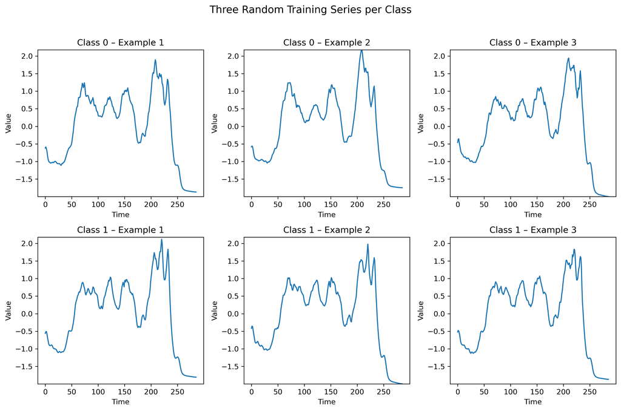

```python
# set.seed(YOUR_STUDENT_ID)
np.random.seed(STUDENT_ID % 2**31)

classes = np.unique(y_train)
selected_indices = {}

for cls in classes:
    cls_idx = np.where(y_train == cls)[0]
    selected_indices[cls] = np.random.choice(cls_idx, size=3, replace=False)

all_values = []
for cls in classes:
    for idx in selected_indices[cls]:
        all_values.append(X_train[idx])

all_values = np.concatenate(all_values)
y_min, y_max = all_values.min(), all_values.max()

# Plot
n_rows = len(classes)
n_cols = 3

fig, axes = plt.subplots(n_rows, n_cols, figsize=(12, 4 * n_rows), squeeze=False)

for row, cls in enumerate(classes):
    for col, idx in enumerate(selected_indices[cls]):
        ax = axes[row, col]
        ax.plot(X_train[idx])
        ax.set_title(f"Class {cls} – Example {col+1}")
        ax.set_xlabel("Time")
        ax.set_ylabel("Value")
        ax.set_ylim(y_min, y_max)

fig.suptitle("Three Random Training Series per Class", fontsize=14)
plt.tight_layout(rect=[0, 0, 1, 0.96])
plt.show()
```

The randomly selected training series show that both classes share a broadly similar overall shape, including gradual increases, multiple oscillations, and a sharp decline near the end of the series. Within-class variation appears relatively small, as samples from the same class exhibit similar patterns. However, the separation between classes is not clearly visible from raw time-domain plots alone, suggesting that additional analyses such as autocorrelation and frequency-domain features may be necessary for effective discrimination.

## 2.2 Descriptive statistics

Compute the following for the **training set**, broken down by class:

| Statistic | Class 1 | Class 2 | … |
| --- | --- | --- | --- |
| Number of series |  |  |  |
| Mean (across all time points and series) |  |  |  |
| Standard deviation |  |  |  |
| Min value |  |  |  |
| Max value |  |  |  |
| Series length |  |  |  |

Report the table in your rendered HTML. Are the classes distinguishable by their marginal statistics alone?

```python
stats_rows = []

for cls in np.unique(y_train):
    class_series = X_train[y_train == cls]
    class_values = class_series.flatten()

    stats_rows.append({
        "Class": cls,
        "Number of series": class_series.shape[0],
        "Mean": np.mean(class_values),
        "Standard deviation": np.std(class_values, ddof=1),
        "Min value": np.min(class_values),
        "Max value": np.max(class_values),
        "Series length": class_series.shape[1]
    })

stats_table = pd.DataFrame(stats_rows)

for col in ["Mean", "Standard deviation", "Min value", "Max value"]:
    stats_table[col] = stats_table[col].round(6)

stats_table
```

|  | Class | Number of series | Mean | Standard deviation | Min value | Max value | Series length |
| --- | --- | --- | --- | --- | --- | --- | --- |
| 0 | 0 | 14 | 0.0 | 0.998375 | -2.064161 | 2.177111 | 286 |
| 1 | 1 | 14 | 0.0 | 0.998375 | -2.008013 | 2.120160 | 286 |

The class-wise descriptive statistics are extremely similar. Both classes contain the same number of training series and have identical series length. Their means are essentially zero, their standard deviations are the same up to the reported precision, and their minimum and maximum values are also very close. This suggests that the two classes are not distinguishable by marginal statistics alone. Any useful separation is therefore more likely to come from temporal structure, such as autocorrelation patterns or frequency-domain characteristics, rather than simple distributional summaries.

## 2.3 ACF analysis

Pick **one representative series per class** (e.g. the series closest to the class mean in Euclidean distance). Compute and plot the ACF up to lag $h = \lfloor L/4 \rfloor$, where $L$ is the series length. Include the 95% confidence bands $\pm 1.96/\sqrt{L}$.

1. Does either class show significant periodic structure? If so, at what lag?
2. Do the two ACF profiles differ? Describe the difference concisely.

```
Class 0: representative series index = 9
Class 1: representative series index = 25
```

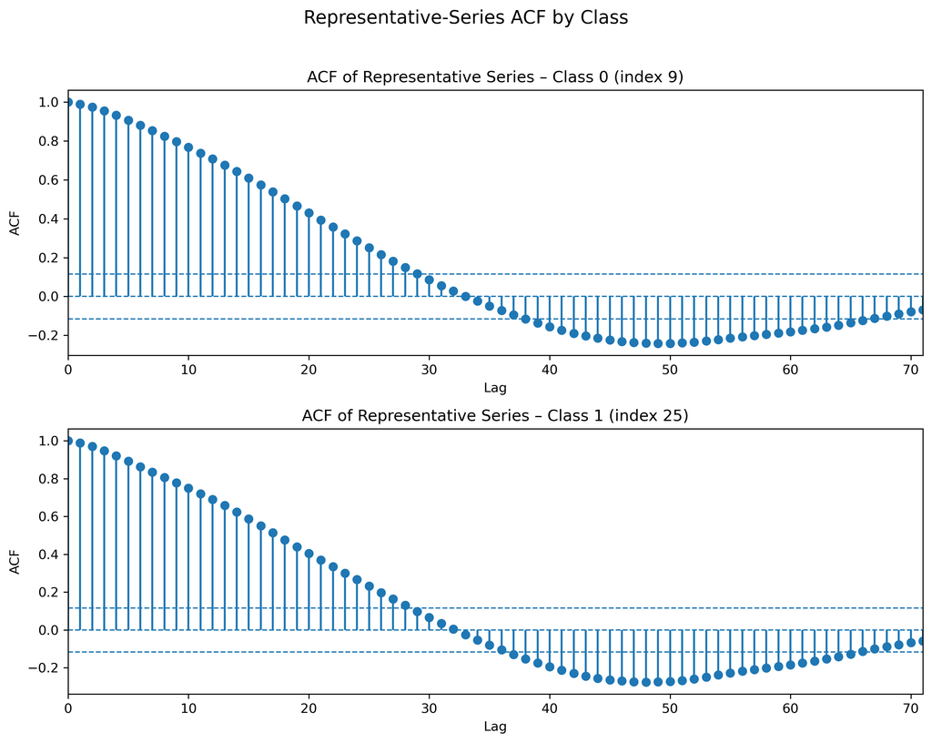

```python
from statsmodels.tsa.stattools import acf

classes = np.unique(y_train)
L = X_train.shape[1]
max_lag = L // 4
conf_band = 1.96 / np.sqrt(L)

representatives = {}
rep_indices = {}

for cls in classes:
    class_series = X_train[y_train == cls]
    class_mean_series = np.mean(class_series, axis=0)

    distances = np.linalg.norm(class_series - class_mean_series, axis=1)
    best_local_idx = np.argmin(distances)
    global_idx = np.where(y_train == cls)[0][best_local_idx]

    representatives[cls] = class_series[best_local_idx]
    rep_indices[cls] = global_idx

for cls in classes:
    print(f"Class {cls}: representative series index = {rep_indices[cls]}")

fig, axes = plt.subplots(len(classes), 1, figsize=(10, 4 * len(classes)), squeeze=False)

for row, cls in enumerate(classes):
    x_rep = representatives[cls]
    acf_vals = acf(x_rep, nlags=max_lag, fft=False)
    lags = np.arange(len(acf_vals))

    ax = axes[row, 0]
    ax.stem(lags, acf_vals, basefmt=" ")
    ax.axhline(0, linestyle="--", linewidth=1)
    ax.axhline(conf_band, linestyle="--", linewidth=1)
    ax.axhline(-conf_band, linestyle="--", linewidth=1)

    ax.set_title(f"ACF of Representative Series – Class {cls} (index {rep_indices[cls]})")
    ax.set_xlabel("Lag")
    ax.set_ylabel("ACF")
    ax.set_xlim(0, max_lag)

fig.suptitle("Representative-Series ACF by Class", fontsize=14)
plt.tight_layout(rect=[0, 0, 1, 0.96])
plt.show()
```

## 2.4 Stationarity check

Apply the **Augmented Dickey–Fuller (ADF) test** to 5 randomly selected training series from each class (10 series total). Report the p-values.

```
Series   Class   ADF p-value   Decision (stationary?)
-------  ------  -----------   ----------------------
  1        1
  2        1
  ...
```

*Brief interpretation: are the series (approximately) stationary? Does it matter for the analyses that follow? (2–3 sentences)*

```python
from statsmodels.tsa.stattools import adfuller

classes = np.unique(y_train)
n_per_class = 5

adf_rows = []

for cls in classes:
    cls_idx = np.where(y_train == cls)[0]
    chosen_idx = np.random.choice(cls_idx, size=n_per_class, replace=False)

    for idx in chosen_idx:
        series = X_train[idx]
        adf_result = adfuller(series)
        p_value = adf_result[1]

        adf_rows.append({
            "Series": idx,
            "Class": cls,
            "ADF p-value": p_value,
            "Decision (stationary?)": "Yes" if p_value < 0.05 else "No"
        })

adf_table = pd.DataFrame(adf_rows).sort_values(["Class", "Series"]).reset_index(drop=True)
adf_table["ADF p-value"] = adf_table["ADF p-value"].round(6)

adf_table
```

|  | Series | Class | ADF p-value | Decision (stationary?) |
| --- | --- | --- | --- | --- |
| 0 | 0 | 0 | 0.160608 | No |
| 1 | 1 | 0 | 0.286023 | No |
| 2 | 3 | 0 | 0.170975 | No |
| 3 | 8 | 0 | 0.353391 | No |
| 4 | 11 | 0 | 0.158786 | No |
| 5 | 20 | 1 | 0.207162 | No |
| 6 | 21 | 1 | 0.240296 | No |
| 7 | 22 | 1 | 0.290921 | No |
| 8 | 24 | 1 | 0.314695 | No |
| 9 | 26 | 1 | 0.356205 | No |

The ADF test results show that all selected series have p-values greater than 0.05, meaning that the null hypothesis of a unit root cannot be rejected. This suggests that the series are not stationary. However, this is consistent with the observed smooth trends and slow decay in the ACF. While strict stationarity is not satisfied, this does not critically affect the analyses that follow, since the focus is on pattern comparison and feature extraction rather than formal time series modeling.

# 3 Part 2 — Missing Data Simulation (25 pts)

Real-world time series often arrive with gaps: sensor dropouts, transmission errors, or irregular sampling. This section asks you to simulate missing data and evaluate imputation strategies.

## 3.1 Introduce missingness

Randomly mask **10% of the time-index positions** in every training series. Use your student ID as the random seed so your results are reproducible.

- Generate a single missing-index mask *per series* (each series gets its own random mask).
- Replace masked values with `NaN`.
- Do **not** modify the test set — it remains complete.

```r
# set.seed(YOUR_STUDENT_ID)
# n_missing <- floor(0.10 * L)
# For each series: sample n_missing positions without replacement → set to NA
# YOUR CODE HERE
```

```python
X_train_missing = X_train.copy()

L = X_train.shape[1]
n_missing = int(np.floor(0.10 * L))

missing_masks = []

for i in range(X_train.shape[0]):
    missing_idx = np.random.choice(L, size=n_missing, replace=False)
    missing_masks.append(missing_idx)
    X_train_missing[i, missing_idx] = np.nan
```

## 3.2 Imputation strategies

Implement the following three strategies and apply each to **all training series**:

| Strategy | Description |
| --- | --- |
| **Mean fill** | Replace each `NaN` with the *series mean* (computed from observed values only) |
| **Linear interpolation** | Linearly interpolate between the two nearest observed neighbours |
| **Moving-average fill** | Replace each `NaN` with the average of the nearest $w$ observed values on each side; use $w = 5$ |

Report the wall-clock time (or relative speed) of each strategy on your dataset.

```python
import time

# Mean fill
def mean_fill_all(X_missing):
    X_filled = X_missing.copy()

    for i in range(X_filled.shape[0]):
        series = X_filled[i]
        mean_val = np.nanmean(series)
        nan_mask = np.isnan(series)
        series[nan_mask] = mean_val
        X_filled[i] = series

    return X_filled


# Linear interpolation
def linear_interp_all(X_missing):
    X_filled = X_missing.copy()
    x = np.arange(X_filled.shape[1])

    for i in range(X_filled.shape[0]):
        series = X_filled[i]
        nan_mask = np.isnan(series)
        obs_mask = ~nan_mask

        series[nan_mask] = np.interp(x[nan_mask], x[obs_mask], series[obs_mask])
        X_filled[i] = series

    return X_filled


# Moving-average fill
def moving_average_fill_series(series, w=5):
    filled = series.copy()
    nan_positions = np.where(np.isnan(filled))[0]

    for pos in nan_positions:
        left_vals = []
        j = pos - 1
        while j >= 0 and len(left_vals) < w:
            if not np.isnan(filled[j]):
                left_vals.append(filled[j])
            j -= 1

        right_vals = []
        j = pos + 1
        while j < len(filled) and len(right_vals) < w:
            if not np.isnan(filled[j]):
                right_vals.append(filled[j])
            j += 1

        neighbors = left_vals + right_vals

        if len(neighbors) > 0:
            filled[pos] = np.mean(neighbors)
        else:
            filled[pos] = np.nanmean(filled)

    return filled


def moving_average_fill_all(X_missing, w=5):
    X_filled = X_missing.copy()

    for i in range(X_filled.shape[0]):
        X_filled[i] = moving_average_fill_series(X_filled[i], w=w)

    return X_filled


# Timing
timing_rows = []

start = time.perf_counter()
X_train_mean = mean_fill_all(X_train_missing)
elapsed_mean = time.perf_counter() - start
timing_rows.append({"Strategy": "Mean fill", "Time (seconds)": elapsed_mean})

start = time.perf_counter()
X_train_linear = linear_interp_all(X_train_missing)
elapsed_linear = time.perf_counter() - start
timing_rows.append({"Strategy": "Linear interpolation", "Time (seconds)": elapsed_linear})

start = time.perf_counter()
X_train_ma = moving_average_fill_all(X_train_missing, w=5)
elapsed_ma = time.perf_counter() - start
timing_rows.append({"Strategy": "Moving-average fill (w=5)", "Time (seconds)": elapsed_ma})

timing_table = pd.DataFrame(timing_rows)
timing_table["Time (seconds)"] = timing_table["Time (seconds)"].round(6)
timing_table
```

|  | Strategy | Time (seconds) |
| --- | --- | --- |
| 0 | Mean fill | 0.000815 |
| 1 | Linear interpolation | 0.000376 |
| 2 | Moving-average fill (w=5) | 0.013664 |

## 3.3 Effect on ACF

Take the **same representative series** you used in §1.3 (one per class). For each imputation strategy, compute the ACF on the imputed series and overlay it on the ACF of the *original* (un-masked) series.

*Deliverable: one figure per class (4 ACF curves per figure: original + 3 strategies). One paragraph per class explaining which strategy best preserves the ACF structure and why.*

**TipWhat to look for**

Mean fill inserts sharp “spikes” of constant value — this creates **artificial autocorrelation** at all lags. Linear interpolation introduces local smoothness that can **inflate** short-lag autocorrelation. Moving-average fill is usually closest to the true ACF when the true series is smooth. Verify whether this holds for your dataset.

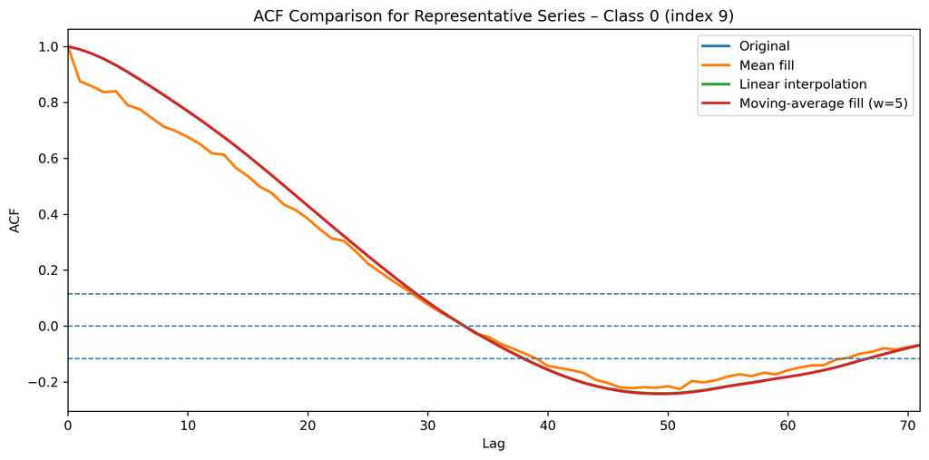

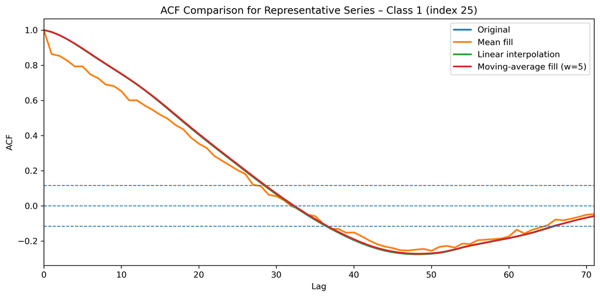

```python
from statsmodels.tsa.stattools import acf

L = X_train.shape[1]
max_lag = L // 4
conf_band = 1.96 / np.sqrt(L)

classes = np.unique(y_train)

for cls in classes:
    idx = rep_indices[cls]

    original_series = X_train[idx]
    mean_series = X_train_mean[idx]
    linear_series = X_train_linear[idx]
    ma_series = X_train_ma[idx]

    acf_original = acf(original_series, nlags=max_lag, fft=False)
    acf_mean = acf(mean_series, nlags=max_lag, fft=False)
    acf_linear = acf(linear_series, nlags=max_lag, fft=False)
    acf_ma = acf(ma_series, nlags=max_lag, fft=False)

    lags = np.arange(max_lag + 1)

    plt.figure(figsize=(10, 5))
    plt.plot(lags, acf_original, label="Original", linewidth=2)
    plt.plot(lags, acf_mean, label="Mean fill", linewidth=2)
    plt.plot(lags, acf_linear, label="Linear interpolation", linewidth=2)
    plt.plot(lags, acf_ma, label="Moving-average fill (w=5)", linewidth=2)

    plt.axhline(0, linestyle="--", linewidth=1)
    plt.axhline(conf_band, linestyle="--", linewidth=1)
    plt.axhline(-conf_band, linestyle="--", linewidth=1)

    plt.title(f"ACF Comparison for Representative Series – Class {cls} (index {idx})")
    plt.xlabel("Lag")
    plt.ylabel("ACF")
    plt.xlim(0, max_lag)
    plt.legend()
    plt.tight_layout()
    plt.show()
```

For Class 0, both linear interpolation and moving-average imputation closely match the original ACF, with almost indistinguishable curves across most lags. The moving-average method appears slightly smoother and marginally closer in some regions, but the difference is minimal. In contrast, mean fill deviates more clearly, especially at lower lags where it reduces autocorrelation. Overall, both linear interpolation and moving-average imputation preserve the temporal structure well, with no substantial difference between them.

A similar pattern is observed for Class 1. Linear interpolation and moving-average imputation produce ACF curves that are nearly identical to the original, indicating that both methods preserve the temporal dependence structure effectively. Any differences between these two methods are very minor and not practically significant. Mean fill again shows the largest deviation, flattening the ACF and weakening the correlation structure.

## 3.4 Imputation choice

Based on the ACF comparison, which strategy would you use for downstream analysis? Justify your choice in 3–4 sentences. Are there situations where a different choice might be preferable?

I would choose moving-average imputation for downstream analysis. The ACF results show that mean fill distorts the dependence structure, while both linear interpolation and moving-average fill closely match the original ACF. Although the difference between these two is small, moving-average fill is slightly preferable because it better preserves local structure using nearby observed values. However, linear interpolation would also be a reasonable alternative, especially when computational simplicity and speed are important.